# **Missing Data Report - Water Quality - Nitrate**

# **National level**

The barplots show the level of missing data at a national level per month and per year (as percentage):

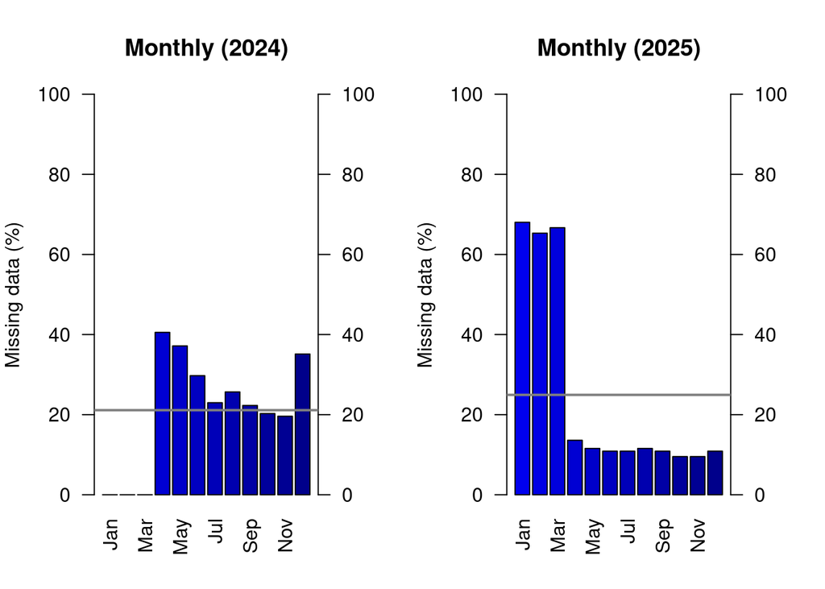

```r
# Round up value to even
lay_n <- round_up_even(length(param$years))
# Plot
par(mar=c(4,4,4,4))
layout(matrix(1:lay_n, ncol=2, byrow=TRUE))
# Yearly change by month
for(i in 1:length(param$years)) {
    plot_miss_nat_yearly_month(x=LSN_missing_nat_percent[[i]] |> unlist(), title=paste0("Monthly (", param$years[i], ")"), names.arg=format(ISOdate(2010,1:12, 1),"%b"))
}
```

And the mean monthly values:

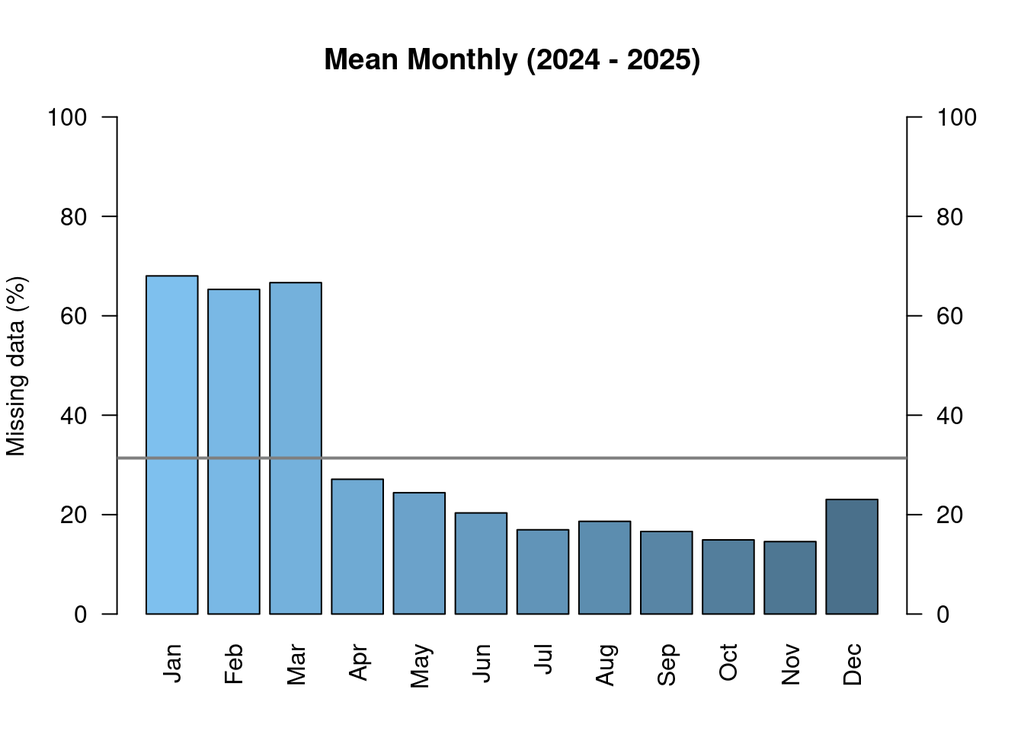

```r
# Average monthly
par(mar=c(4,4,4,4))
plot_miss_nat_yearly_month(x=LSN_missing_nat_totals_pc, title=paste0("Mean Monthly (", yr[1], " - ", yr[2], ")"), col=colorRampPalette(c("skyblue2", "skyblue4"))(12))
```

The mean level (%) of missing data per year is:

```r
# Format table to show mean misisng data per year
tbl_data_year_missing <- data.frame(Year = param$years, Missing = unlist(lapply(LSN_missing_nat_percent, \(x) round(mean(unlist(x)), 1))))
dt_year_missing <- datatable(tbl_data_year_missing, options = list(dom = 't', paging = FALSE, autoWidth = TRUE), rownames = FALSE, width = "20")

dt_year_missing
```

| Year | Missing |
| --- | --- |
| 2024 | 21.1 |
| 2025 | 24.9 |

```r
# Format table to show mean misisng data per year
tbl_data_month_missing <- data.frame(Month = format(ISOdate(2010,1:12, 1), "%B"), Missing = round(LSN_missing_nat_totals_pc, 1))
dt_month_missing <- DT::datatable(tbl_data_month_missing, options = list(dom = 't', paging = FALSE, autoWidth = TRUE), rownames = FALSE, width = "20")

dt_month_missing
```

| Month | Missing |
| --- | --- |
| January | 68 |
| February | 65.3 |
| March | 66.7 |
| April | 27.1 |
| May | 24.4 |
| June | 20.3 |
| July | 16.9 |
| August | 18.6 |
| September | 16.6 |
| October | 14.9 |

[output cut: 2 more lines]

## **Littles MCAR Test**

National level missing data was tested to see whether it should be considered Missing Completely at Random (MCAR). This test helps determine whether the pattern of missing measurements appears systematic or essentially unrelated to the data. These results should be considered as supporting evidence of the type of missing data (if no results are shown, it means test was not run due to too much missing data):

```r
# Skip this for variables with too much missing data (it fails)
skip_mcar <- FALSE
if(param$st=="LS" & param$fnn=="Nitrogen") {skip_mcar <- TRUE}
if(skip_mcar==FALSE) {
# Run test for each year
mcar_res <- lapply(LSN_wide, \(x) littles_mcar_test(x[, -c(1, 2)]))
# Convert results
res_dt <- rbindlist(lapply(mcar_res, as.data.table))
res_dt[, `:=`(statistic = as.integer(round(statistic)), p.value = round(p.value, 4))]
# As DT for report display
res_dt[, year := param$years]
setcolorder(res_dt, "year")
# Change to DT for display
res_dt <- DT::datatable(res_dt, options = list(dom = 't', paging = FALSE, autoWidth = FALSE), rownames = FALSE, width = "auto")}
```

For datasets with very high levels of missing data the test may not be estimable and therefore no results is presented. P values that are not significant (greater than 0.05) suggest that the data could be considered MCAR. Where the p value is significant (less than 0.05), the data can not be considered MCAR. The data will either be Missing at Random (MAR), or Missing Not at Random (MNAR).

# **Regional level**

The heatmaps show the level of missing data at a regional level (e.g. by river basin district) per month and per year (as percentage):

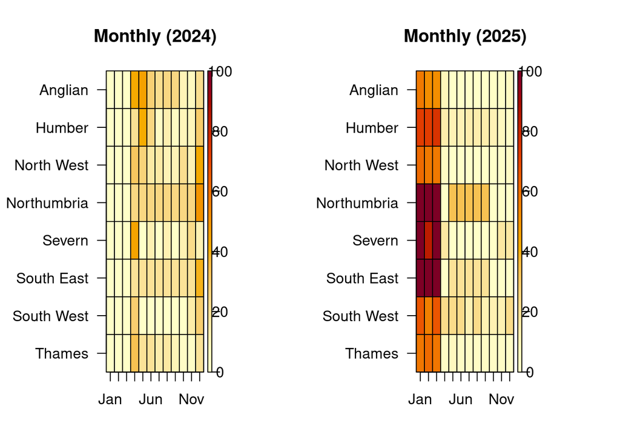

```r
# Plot
par(mar=c(4,4,4,4))
layout(matrix(1:lay_n, ncol=2, byrow=TRUE))
# Heatmaps
for(i in 1:length(param$years)) {
    plot_miss_heatmap(x=LSN_missing_rbd_percent[[i]][, .SD, .SDcols=LSN_wide_names[[i]]] |> as.matrix(), xlabs=format(ISOdate(2010,1:12, 1),"%b"), ylabs=LSN_missing_rbd_percent[[i]][, ea_rbd], title=paste0("Monthly (", param$years[i], ")"), lta=0.5)
}
```

The mean level (%) of missing data per RBD per year is:

```r
# Format table/results
LSN_missing_rbd_yearly_mean <- lapply(LSN_missing_rbd_percent, \(x) round(x[, yearly_mean], 1)) |> do.call(cbind, args=_)
colnames(LSN_missing_rbd_yearly_mean) <- param$year
LSN_missing_rbd_yearly_mean <- data.table(RBD = as.character(LSN_missing_rbd_percent[[1]][, ea_rbd]), LSN_missing_rbd_yearly_mean)
# DT for pretty table
LSN_missing_rbd_yearly_mean_dt <- DT::datatable(LSN_missing_rbd_yearly_mean, options = list(dom = 't', paging = FALSE, autoWidth = TRUE), rownames = FALSE, width = "20")

LSN_missing_rbd_yearly_mean_dt
```

| RBD | 2024 | 2025 |
| --- | --- | --- |
| Anglian | 18.4 | 15 |
| Humber | 12.8 | 26.4 |
| North West | 15.4 | 15.5 |
| Northumbria | 20.8 | 38.9 |
| Severn | 9.3 | 27.8 |
| South East | 16.7 | 33.3 |
| South West | 6 | 28.7 |
| Thames | 11.7 | 17.5 |

# **Site level**

The maps show the level of missing data at a site level, with the number of missing months per site per year:

```r
### Create SF objects to plot maps
# Add geometry
lapply(1:length(param$years), \(x) LSN_wide[[x]][LSN_sites_filtered, geometry := i.geometry, on="network_id"])
# add percent missing data
lapply(1:length(param$years), \(x) LSN_wide[[x]][, missing_count_pc := missing_count / 12 * 100])
# Create sf object for plotting (total missing per year)
LSN_wide_sf <- lapply(1:length(param$years), \(x) st_as_sf(LSN_wide[[x]][, .(missing_count, missing_count_pc, geometry)]))
# create categories
months <- format(ISOdate(2010,1:12,1), "%b")
missing_cat <- lapply(1:length(param$years), \(x) apply(LSN_wide[[x]][, .SD, .SDcols=LSN_wide_names[[x]]], 2, \(x) ifelse(is.na(x), "Missing", "Not Missing")))
# rename
for(i in 1:length(param$years)) { colnames(missing_cat[[i]]) <- months}
# Add to sf
LSN_wide_sf <- lapply(1:length(param$years), \(x) cbind(LSN_wide_sf[[x]], missing_cat[[x]]))
```

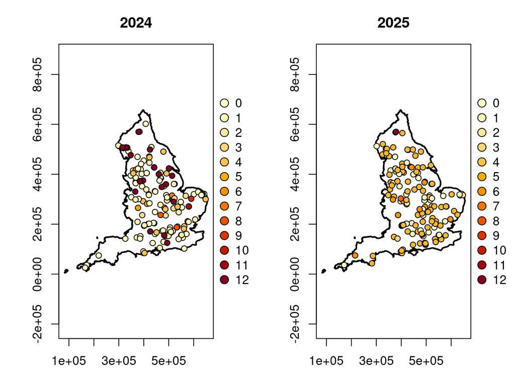

```r
### Plot
# Create colour maps (custom function)
mcols <- vector("list", length(LSN_wide_sf))
for(i in 1:length(LSN_wide_sf)) {mcols[[i]] <- col_map(x=LSN_wide_sf[[i]]$missing_count)}
lcol <- hcl.colors(13, "YlOrRd", rev = TRUE) # needs to match what went into the colour map
#
par(mar=c(2, 4, 3, 3))
layout(matrix(1:lay_n, ncol=2, byrow=TRUE))
brks <- 0:12
# Maps
for(i in 1:length(param$years)) {
    plot(st_geometry(sh_eng), lwd = 2, axes=TRUE, main=param$years[i])
    plot(LSN_wide_sf[[i]]["missing_count"], pch=21, col="black", bg=mcols[[i]], add=TRUE)
    legend(x = par("usr")[2], y = mean(par("usr")[3:4]), legend=brks, pt.bg=lcol, pch=21, pt.cex=1.5, xpd = NA, bty = "n", yjust = 0.5)
}
```

## **Missing data by site**

The sites with the highest level of missing data are (only shows the first 20 rows):

```r
sites_miss_dt <- datatable(LSN_site_miss_table[1:20,], colnames=c("ID", "Site status", "RBD", "No. Years", "Missing data", "Missing data %"))

sites_miss_dt
```

|  | ID | Site status | RBD | No. Years | Missing data | Missing data % |
| --- | --- | --- | --- | --- | --- | --- |
| 1 | LSN0363 | Active |  | 1 | 12 | 100 |
| 2 | LSN0365 | Active |  | 1 | 12 | 100 |
| 3 | LSN0379 | Active |  | 1 | 12 | 100 |
| 4 | LSN0385 | Active |  | 2 | 24 | 100 |
| 5 | LSN0337 | Active |  | 2 | 21 | 87.5 |
| 6 | LSN0356 | Active |  | 2 | 21 | 87.5 |
| 7 | LSN0360 | Active |  | 2 | 21 | 87.5 |
| 8 | LSN0060 | Active | North West | 1 | 9 | 75 |
| 9 | LSN0095 | Active | Humber | 1 | 9 | 75 |
| 10 | LSN0031 | Active |  | 1 | 9 | 75 |

[output cut: 10 more lines]

A full table of results can be found in the `outputs/tables` folder